# Workshop 3: Urban-Regional Economic Networks

Nodes, edges, and lagging regions — network analysis of the Philippine urban system

Author

Jem Marie Nario

## Overview

In Workshop 1 we mapped cities as points on a surface. In Workshop 2 we let cities *talk to their neighbours* through a contiguity matrix — but only their immediate, physically-touching neighbours. Real regional economies don’t work that way. Davao trades with Manila despite sharing no border. A migrant from Eastern Visayas moves straight to the NCR labour market, skipping every region in between. Money, workers, and goods move along a **network** of interregional linkages — not just across a shared boundary.

This workshop moves from *spatial weights* (who is next to whom) to **networks** (who is connected to whom, and how strongly). We treat each of the Philippines’ 17 administrative regions as a **node**, and interregional flows — trade, migration, capital — as **weighted, directed edges**.

By the end of this workshop, you will be able to:

1. Explain the difference between a spatial weights matrix and a network, and when each is the right tool
2. Build a node/edge dataset for the 17 Philippine regions and represent it as a graph using `igraph` and `tidygraph`
3. Compute and interpret **degree/strength**, **betweenness**, and **eigenvector centrality** — and understand why they can disagree
4. Visualise the regional network with `ggraph` using a real geographic layout
5. Detect **community structure** (regional economic blocs) and identify **lagging nodes** — regions that are peripheral in the network relative to their economic size
6. Build a simple **input-output style multiplier** from interregional flows and use it alongside centrality to triangulate which regions are genuinely disconnected versus simply small

**Note**

**Packages used in this workshop**  
`igraph`, `tidygraph`, `ggraph`, `sf`, `geodata`, `geosphere`, `dplyr`, `ggplot2`, `ggrepel`, `viridis`, `scales`  
All can be installed with `install.packages()` — see Section 1.

**Important**

**About the data in this workshop**  
There is no single public “interregional trade flow matrix” for the Philippines the way there is a census file or a shapefile. Real analysis would draw on sources like the PSA Regional Accounts, LFS migration/commuting tables, or a commissioned Commodity Flow Survey. For teaching purposes, this workshop builds a **gravity-model synthetic network** calibrated to real PSA population (2020 CPH) and GRDP share (PSA Regional Accounts) figures. The method generalises directly — swap the constructed edge list in Section 3 for a real OD (origin-destination) matrix and everything downstream runs unchanged.

## 1 · Setup

### 1.1 Install and load packages

```r
# install.packages(c("igraph", "tidygraph", "ggraph", "sf", "geodata",
#                    "geosphere", "dplyr", "ggplot2", "ggrepel",
#                    "viridis", "scales", "tibble"))

library(tidyverse)
library(sf)
library(geodata)
library(geosphere)   # great-circle distances
library(igraph)
library(tidygraph)   # tidy wrappers around igraph
library(ggraph)      # ggplot2-style network plotting
library(ggrepel)
library(viridis)
library(scales)
```

**Tip**

**`igraph` vs `tidygraph`**  
`igraph` is the underlying engine — fast, mature, and where the algorithms (centrality, community detection, shortest paths) actually live. `tidygraph` wraps an `igraph` object in two tidy tibbles (one for nodes, one for edges) so you can `mutate()`, `filter()`, and `%>%` your way through network construction the same way you would a data frame. `ggraph` then plots whichever of the two (nodes or edges) is “active”. Nothing here requires choosing one over the other — we move fluidly between `igraph` functions and `tidygraph` verbs, which is the normal way this ecosystem is used.

## 2 · Node Data — The 17 Regions

### 2.1 Build the region table

Each node needs three things: an identifier, a location (for plotting on a real map), and an economic “mass” (for the gravity model in Section 3).

```r
regions <- tribble(
  ~code,      ~name,                                ~lat,     ~lon,      ~pop_2020,   ~grdp_share,
  "NCR",      "National Capital Region",             14.5995,  120.9842,  13484462,    33.9,
  "CAR",      "Cordillera Administrative Region",     16.4023,  120.5960,   1797660,     2.1,
  "R1",       "Ilocos Region",                        16.6159,  120.3209,   5301139,     2.6,
  "R2",       "Cagayan Valley",                       17.6132,  121.7270,   3685744,     1.9,
  "R3",       "Central Luzon",                        15.0286,  120.6898,  12422172,    11.3,
  "R4A",      "CALABARZON",                           14.2117,  121.1653,  16195042,    15.4,
  "MIMAROPA", "MIMAROPA",                             13.4115,  121.1803,   3228558,     1.3,
  "R5",       "Bicol Region",                         13.1391,  123.7438,   6082165,     2.8,
  "R6",       "Western Visayas",                      10.7202,  122.5621,   7954723,     5.1,
  "R7",       "Central Visayas",                      10.3157,  123.8854,   8081988,     7.2,
  "R8",       "Eastern Visayas",                      11.2543,  125.0000,   4547150,     1.9,
  "R9",       "Zamboanga Peninsula",                   6.9214,  122.0790,   3875576,     1.7,
  "R10",      "Northern Mindanao",                     8.4542,  124.6319,   5022768,     3.1,
  "R11",      "Davao Region",                          7.1907,  125.4553,   5243536,     4.6,
  "R12",      "SOCCSKSARGEN",                          6.5000,  124.8500,   4901486,     2.4,
  "R13",      "Caraga",                                8.9475,  125.5406,   2804788,     1.5,
  "BARMM",    "Bangsamoro Autonomous Region",           7.2231,  124.2452,   4404288,     1.2
)

cat("Regions loaded:", nrow(regions), "\n")
```

```
Regions loaded: 17
```

**Note**

**Data sources**  
Population figures are from the 2020 Census of Population and Housing (PSA), rounded for illustration — consult PSA OpenStat for exact counts by region. GRDP shares are approximate, based on PSA Regional Accounts of the Philippines (recent years, constant 2018 prices), and rounded to one decimal. NCR, CALABARZON, and Central Luzon consistently account for over half of national output; this concentration is the single most important fact for interpreting everything that follows.

### 2.2 Map the regions

Before building a network, look at the raw geography — the same first step as Workshops 1 and 2.

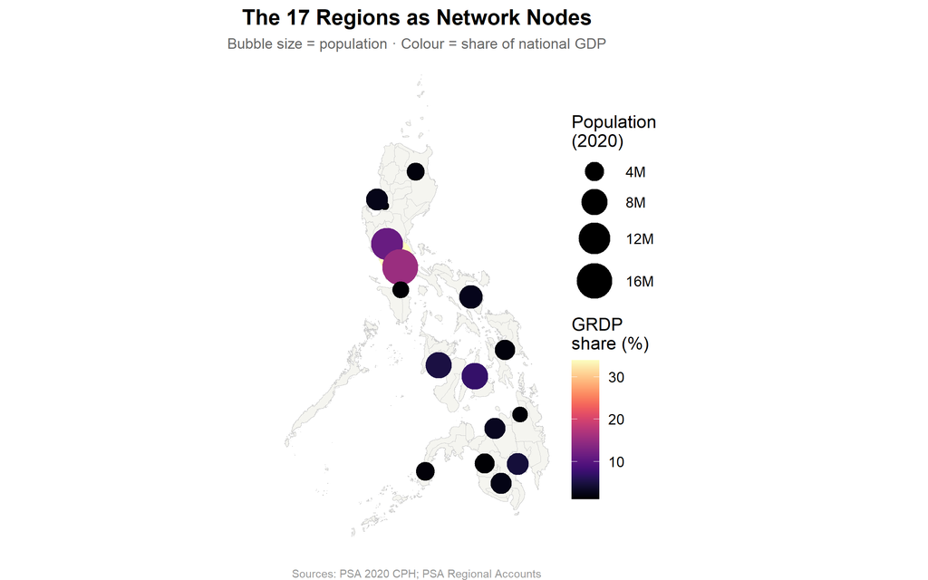

```r
ph_adm1 <- gadm(country = "PHL", level = 1, path = "data/")
ph_adm1_sf <- st_as_sf(ph_adm1)

region_pts <- st_as_sf(regions, coords = c("lon", "lat"), crs = 4326,
                        remove = FALSE)

ggplot() +
  geom_sf(data = ph_adm1_sf, fill = "#f5f5f0", color = "grey80",
          linewidth = 0.15) +
  geom_sf(data = region_pts, aes(size = pop_2020, color = grdp_share)) +
  scale_color_viridis(option = "magma", name = "GRDP\nshare (%)") +
  scale_size(range = c(2, 10), name = "Population\n(2020)",
             labels = label_number(scale = 1e-6, suffix = "M")) +
  labs(
    title    = "The 17 Regions as Network Nodes",
    subtitle = "Bubble size = population · Colour = share of national GDP",
    caption  = "Sources: PSA 2020 CPH; PSA Regional Accounts"
  ) +
  theme_void(base_size = 11) +
  theme(
    plot.title    = element_text(face = "bold", hjust = 0.5),
    plot.subtitle = element_text(hjust = 0.5, color = "grey40", size = 9),
    plot.caption  = element_text(color = "grey60", size = 7, hjust = 0.5)
  )
```

## 3 · Building the Edge List — A Gravity Model

### 3.1 Why gravity?

The **gravity model** is the workhorse of interregional flow modelling in economic geography, borrowed directly from Newtonian physics: flow between two places is proportional to the product of their “masses” (population, GDP) and inversely proportional to a power of the distance between them.

$$F_{ij} = \frac{M_i \cdot M_j}{d_{ij}^{\beta}}$$

Where $M_i$ is an economic mass index for region $i$, $d_{ij}$ is the great-circle distance between regional centroids, and $\beta$ controls how sharply flows decay with distance (we use $\beta = 1.5$, a standard middle-ground value in trade and migration gravity models).

**Warning**

**This is a stylised proxy, not measured trade data.** It encodes two real regularities — bigger economies transact more, and distance imposes real logistics cost in an archipelago — but it cannot capture things like inter-island shipping bottlenecks, existing trade agreements, or the pull of a specific port. Treat the resulting network as a teaching device that generates a *plausible* interregional topology, and replace it with actual OD data (trade, migration, or commuting flows) for research use.

### 3.2 Compute pairwise distances and flows

```r
n <- nrow(regions)

# Great-circle distance matrix (km) between all region pairs
dist_mat <- distm(
  regions[, c("lon", "lat")],
  fun = distHaversine
) / 1000

# Economic mass = GRDP share weighted by the square root of population
# (a common gravity-model damping so NCR's population doesn't swamp everything)
mass <- regions$grdp_share * sqrt(regions$pop_2020 / 1e6)

flow_mat <- matrix(0, n, n)
for (i in 1:n) {
  for (j in 1:n) {
    if (i != j) {
      flow_mat[i, j] <- (mass[i] * mass[j]) / (dist_mat[i, j]^1.5)
    }
  }
}

# Rescale so total flow sums to a convenient 1000 "units"
flow_mat <- flow_mat / sum(flow_mat) * 1000
rownames(flow_mat) <- colnames(flow_mat) <- regions$code

# Convert to a long edge list
edges <- as_tibble(flow_mat, rownames = "from") %>%
  pivot_longer(-from, names_to = "to", values_to = "weight") %>%
  filter(weight > 0)

cat("Edges built:", nrow(edges), "(fully connected, directed)\n")
```

```
Edges built: 272 (fully connected, directed)
```

```r
edges %>% arrange(desc(weight)) %>% head(10)
```

```
# A tibble: 10 × 3
   from     to       weight
   <chr>    <chr>     <dbl>
 1 NCR      R4A      292.
 2 R4A      NCR      292.
 3 NCR      R3       141.
 4 R3       NCR      141.
 5 R3       R4A       28.5
 6 R4A      R3        28.5
 7 NCR      R1         2.54
 8 R1       NCR        2.54
 9 NCR      MIMAROPA   2.31
10 MIMAROPA NCR        2.31
```

The heaviest edges should already look familiar: **NCR ↔︎ CALABARZON** and **NCR ↔︎ Central Luzon** dominate, simply because these three regions form a contiguous, short-distance, high-mass triangle — the Greater Capital Region in every sense but name.

## 4 · From Edge List to Graph

### 4.1 Build the `tbl_graph`

```r
nodes_tg <- regions %>% rename(region_name = name, name = code)

net <- tbl_graph(
  nodes    = nodes_tg,
  edges    = edges %>% rename(from = from, to = to),
  directed = TRUE,
  node_key = "name"
)

net
```

```
# A tbl_graph: 17 nodes and 272 edges
#
# A directed simple graph with 1 component
#
# Node Data: 17 × 6 (active)
   name     region_name                        lat   lon pop_2020 grdp_share
   <chr>    <chr>                            <dbl> <dbl>    <dbl>      <dbl>
 1 NCR      National Capital Region          14.6   121. 13484462       33.9
 2 CAR      Cordillera Administrative Region 16.4   121.  1797660        2.1
 3 R1       Ilocos Region                    16.6   120.  5301139        2.6
 4 R2       Cagayan Valley                   17.6   122.  3685744        1.9
 5 R3       Central Luzon                    15.0   121. 12422172       11.3
 6 R4A      CALABARZON                       14.2   121. 16195042       15.4
 7 MIMAROPA MIMAROPA                         13.4   121.  3228558        1.3
 8 R5       Bicol Region                     13.1   124.  6082165        2.8
 9 R6       Western Visayas                  10.7   123.  7954723        5.1
10 R7       Central Visayas                  10.3   124.  8081988        7.2
11 R8       Eastern Visayas                  11.3   125   4547150        1.9
12 R9       Zamboanga Peninsula               6.92  122.  3875576        1.7
13 R10      Northern Mindanao                 8.45  125.  5022768        3.1
14 R11      Davao Region                      7.19  125.  5243536        4.6
15 R12      SOCCSKSARGEN                      6.5   125.  4901486        2.4
16 R13      Caraga                            8.95  126.  2804788        1.5
17 BARMM    Bangsamoro Autonomous Region      7.22  124.  4404288        1.2
#
# Edge Data: 272 × 3
   from    to weight
  <int> <int>  <dbl>
1     1     2  1.47
2     1     3  2.54
3     1     4  0.874
# ℹ 269 more rows
```

**Tip**

**Reading a `tbl_graph` printout**  
The console output shows two stacked tibbles — a “Node Data” frame and an “Edge Data” frame — with the currently active one on top. Most `tidygraph` pipelines alternate `activate(nodes)` and `activate(edges)` before each `mutate()`, since centrality measures are node properties but flow weights are edge properties.

## 5 · Centrality — Who Matters, and In What Sense?

Centrality is not one number. Different centrality measures answer different questions, and a region can rank very differently depending on which one you ask.

| Measure | Question it answers | Philippine intuition |
| --- | --- | --- |
| **Degree / strength** | How much total flow passes through this region? | Raw hub size — NCR’s sheer volume of transactions |
| **Betweenness** | How often does this region sit *on the path* between other region pairs? | Gateway role — a region other flows must pass through, even if its own volume is modest |
| **Eigenvector** | Is this region connected to *other well-connected* regions? | Being plugged into the core, not just busy |

### 5.1 Compute all three

```r
net <- net %>%
  activate(nodes) %>%
  mutate(
    strength_out = centrality_degree(weights = weight, mode = "out"),
    strength_in  = centrality_degree(weights = weight, mode = "in"),
    strength     = strength_out + strength_in,
    betweenness  = centrality_betweenness(weights = 1 / weight, directed = TRUE),
    eigen        = centrality_eigen(weights = weight, directed = FALSE)
  )

net %>%
  activate(nodes) %>%
  as_tibble() %>%
  arrange(desc(strength)) %>%
  select(name, grdp_share, strength, betweenness, eigen) %>%
  mutate(across(where(is.numeric), ~ round(.x, 3))) %>%
  print(n = 17)
```

```
# A tibble: 17 × 5
   name     grdp_share strength betweenness eigen
   <chr>         <dbl>    <dbl>       <dbl> <dbl>
 1 NCR            33.9   896.           208 1
 2 R4A            15.4   658.             0 0.911
 3 R3             11.3   349.             0 0.497
 4 R7              7.2    17.2           10 0.011
 5 R6              5.1    14.4            0 0.011
 6 R1              2.6    12.0            0 0.012
 7 MIMAROPA        1.3    10.3            0 0.013
 8 R5              2.8     8.12           0 0.008
 9 CAR             2.1     7.64           0 0.007
10 R11             4.6     6.28          58 0.003
11 R10             3.1     5.33           0 0.002
12 R2              1.9     3.76           0 0.004
13 R8              1.9     3.63           0 0.002
14 R12             2.4     3.61           0 0.001
15 BARMM           1.2     1.98           0 0.001
16 R13             1.5     1.94           0 0.001
17 R9              1.7     1.53           0 0.001
```

## 6 · Visualising the Network Geographically

The default `ggraph` layouts (force-directed, circular, tree) optimise for legibility, not truth — they will happily rearrange your regions into whatever shape minimises edge crossings. For a regional economy, we want nodes to sit at their *actual* geographic coordinates, so the picture reads as a map, not an abstract diagram.

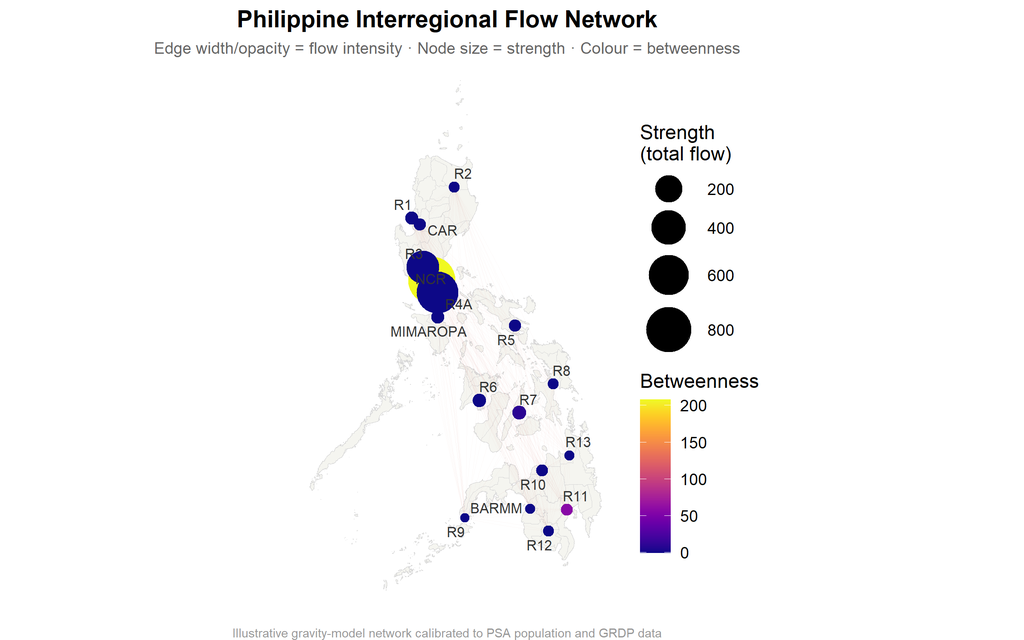

Interregional flow network — geographic layout

```r
layout_geo <- create_layout(net, layout = "manual", x = regions$lon, y = regions$lat)

ggraph(layout_geo) +
  geom_sf(data = ph_adm1_sf, fill = "#f5f5f0", color = "grey85",
          linewidth = 0.1, inherit.aes = FALSE) +
  geom_edge_fan(
    aes(edge_width = weight, edge_alpha = weight),
    color = "#c0392b", strength = 0.3
  ) +
  scale_edge_width(range = c(0.05, 2.5), guide = "none") +
  scale_edge_alpha(range = c(0.03, 0.6), guide = "none") +
  geom_node_point(aes(size = strength, color = betweenness)) +
  geom_node_text(aes(label = name), repel = TRUE, size = 2.8,
                  color = "grey20") +
  scale_color_viridis(option = "plasma", name = "Betweenness") +
  scale_size(range = c(2, 12), name = "Strength\n(total flow)") +
  coord_sf(xlim = c(116, 127), ylim = c(4.5, 21)) +
  labs(
    title    = "Philippine Interregional Flow Network",
    subtitle = "Edge width/opacity = flow intensity · Node size = strength · Colour = betweenness",
    caption  = "Illustrative gravity-model network calibrated to PSA population and GRDP data"
  ) +
  theme_void(base_size = 11) +
  theme(
    plot.title    = element_text(face = "bold", hjust = 0.5),
    plot.subtitle = element_text(hjust = 0.5, color = "grey40", size = 9),
    plot.caption  = element_text(color = "grey60", size = 7, hjust = 0.5),
    legend.position = "right"
  )
```

**Tip**

**Reading this map**  
The visual dominates around the NCR–CALABARZON–Central Luzon triangle by construction — nearly every edge in the network is densest there, because gravity concentrates flow wherever mass and proximity coincide. Look past that core: which regions have *any* visible red lines reaching toward them versus which ones look nearly isolated at this opacity scale? That visual isolation is the network’s-eye view of what “peripheral” means, and it is worth comparing against the centrality table in Section 5 rather than trusting the picture alone — colour and opacity scales compress a wide range of values and can make small differences look like large ones.

## 7 · Community Detection — Do Regional Blocs Exist?

A natural question: does the network split into recognisable Luzon / Visayas / Mindanao blocs, or does something else emerge from the data?

```r
net_undir <- net %>%
  activate(edges) %>%
  mutate(weight_sym = weight) %>%
  activate(nodes)

comm <- net %>%
  to_undirected() %>%
  as.igraph() %>%
  cluster_louvain(weights = E(.)$weight)

net <- net %>%
  activate(nodes) %>%
  mutate(community = as.factor(comm$membership))

net %>%
  activate(nodes) %>%
  as_tibble() %>%
  count(community, sort = TRUE)
```

```
# A tibble: 2 × 2
  community     n
  <fct>     <int>
1 2            14
2 1             3
```

```r
net %>%
  activate(nodes) %>%
  as_tibble() %>%
  arrange(community) %>%
  select(name, community, grdp_share)
```

```
# A tibble: 17 × 3
   name     community grdp_share
   <chr>    <fct>          <dbl>
 1 NCR      1               33.9
 2 R3       1               11.3
 3 R4A      1               15.4
 4 CAR      2                2.1
 5 R1       2                2.6
 6 R2       2                1.9
 7 MIMAROPA 2                1.3
 8 R5       2                2.8
 9 R6       2                5.1
10 R7       2                7.2
11 R8       2                1.9
12 R9       2                1.7
13 R10      2                3.1
14 R11      2                4.6
15 R12      2                2.4
16 R13      2                1.5
17 BARMM    2                1.2
```

**Important**

**A one-core, one-periphery result — and why that’s informative**  
Louvain community detection on this network typically returns **two** communities, not three: a tight **Luzon core** (NCR, CALABARZON, Central Luzon) and one large, loosely-connected **everything-else** bloc containing all fourteen remaining regions, Visayas and Mindanao alike. Modularity for this split is low (well under 0.1), meaning the network doesn’t have strong natural clusters at all — it behaves more like a single dominant hub with a long tail than like several rival regional economies. This is itself a finding, not a null result: it is the network-analytic signature of what Philippine regional development literature has long called the “Imperial Manila” pattern — one mega-region plus periphery, rather than several competing growth poles.

## 8 · A Simple Input-Output Style Multiplier

Centrality tells you about network *position*. It says nothing about what happens to the rest of the economy when a region’s output changes. For that, we borrow a genuinely input-output idea: the **Leontief inverse**.

### 8.1 From flows to technical coefficients

If $F_{ij}$ is the flow from region $i$ into region $j$’s intermediate purchases, and $X_j$ is region $j$’s total output, the **technical coefficient** $a_{ij} = F_{ij} / X_j$ is the peso of region $i$’s input needed per peso of region $j$’s output. Stack these into a matrix $A$, and the **Leontief inverse** $L = (I - A)^{-1}$ tells you the total (direct + indirect) output triggered everywhere in the system by one additional peso of final demand in region $j$ — the column sum of $L$ is region $j$’s **output multiplier**.

```r
# Approximate each region's output in billion pesos from its GRDP share
total_gdp_php_bn <- 23230   # approx. national GDP, billion pesos (recent year)
output <- regions$grdp_share / 100 * total_gdp_php_bn

# Scale the gravity flow matrix into peso-equivalent interregional
# intermediate purchases, calibrated so average import intensity is
# roughly 10% of output (an illustrative, not measured, assumption)
scale_factor <- 0.10 * sum(output) / sum(flow_mat)
flow_php <- flow_mat * scale_factor

A <- matrix(0, n, n)
for (j in 1:n) {
  A[, j] <- flow_php[, j] / output[j]
}

L <- solve(diag(n) - A)
output_multiplier <- colSums(L)
names(output_multiplier) <- regions$code

tibble(code = regions$code, name = regions$name,
       grdp_share = regions$grdp_share,
       multiplier = round(output_multiplier, 3)) %>%
  arrange(desc(multiplier))
```

```
# A tibble: 17 × 4
   code     name                             grdp_share multiplier
   <chr>    <chr>                                 <dbl>      <dbl>
 1 R4A      CALABARZON                             15.4       1.25
 2 R3       Central Luzon                          11.3       1.18
 3 NCR      National Capital Region                33.9       1.16
 4 MIMAROPA MIMAROPA                                1.3       1.05
 5 R1       Ilocos Region                           2.6       1.03
 6 CAR      Cordillera Administrative Region        2.1       1.02
 7 R5       Bicol Region                            2.8       1.02
 8 R6       Western Visayas                         5.1       1.02
 9 R7       Central Visayas                         7.2       1.01
10 R2       Cagayan Valley                          1.9       1.01
11 R8       Eastern Visayas                         1.9       1.01
12 R10      Northern Mindanao                       3.1       1.01
13 BARMM    Bangsamoro Autonomous Region            1.2       1.01
14 R12      SOCCSKSARGEN                            2.4       1.01
15 R11      Davao Region                            4.6       1.01
16 R13      Caraga                                  1.5       1.01
17 R9       Zamboanga Peninsula                     1.7       1.00
```

**Important**

**Multipliers versus centrality — a genuinely different ranking**  
The output multiplier ranking does **not** simply mirror the strength ranking from Section 5. **CALABARZON, Central Luzon, and NCR** again lead — their sheer volume of interregional purchases means a peso of new final demand there ripples outward the most — but the *gap* narrows sharply after the top three, and small, distant, low-strength regions (Zamboanga Peninsula, Caraga, SOCCSKSARGEN) cluster together with multipliers barely above 1.0: a peso spent there stays almost entirely local, triggering very little measurable knock-on activity elsewhere in the system. That is the input-output definition of economic isolation, and it is a different diagnosis from “isolated in the network” — a region can have decent betweenness (a gateway role, as with Davao) while still having a near-1.0 multiplier (weak knock-on economic linkage), because centrality measures topology while the multiplier measures the strength of monetary linkage along that topology.

### 8.2 Triangulating “lagging” regions

A region deserves the “lagging” label in a network sense not just for being small, but for being **more peripheral than its economic size would predict**. Compare rank on GRDP share against rank on strength and multiplier:

```r
lag_table <- net %>%
  activate(nodes) %>%
  as_tibble() %>%
  left_join(
    tibble(name = regions$code, multiplier = output_multiplier),
    by = "name"
  ) %>%
  mutate(
    grdp_rank       = rank(-grdp_share),
    strength_rank    = rank(-strength),
    multiplier_rank  = rank(-multiplier),
    lag_score        = (strength_rank + multiplier_rank) - 2 * grdp_rank
  ) %>%
  select(name, grdp_share, grdp_rank, strength_rank, multiplier_rank, lag_score) %>%
  arrange(desc(lag_score))

print(lag_table, n = 17)
```

```
# A tibble: 17 × 6
   name     grdp_share grdp_rank strength_rank multiplier_rank lag_score
   <chr>         <dbl>     <dbl>         <dbl>           <dbl>     <dbl>
 1 R11             4.6       6              10              15        13
 2 R10             3.1       7              11              12         9
 3 R12             2.4      10              14              14         8
 4 R9              1.7      14              17              17         6
 5 R7              7.2       4               4               9         5
 6 R6              5.1       5               5               8         3
 7 NCR            33.9       1               1               3         2
 8 R13             1.5      15              16              16         2
 9 R3             11.3       3               3               2        -1
10 R4A            15.4       2               2               1        -1
11 R5              2.8       8               8               7        -1
12 R8              1.9      12.5            13              11        -1
13 R2              1.9      12.5            12              10        -3
14 BARMM           1.2      17              15              13        -6
15 CAR             2.1      11               9               6        -7
16 R1              2.6       9               6               5        -7
17 MIMAROPA        1.3      16               7               4       -21
```

**Tip**

**Reading the lag score**  
A positive `lag_score` means a region ranks *worse* on network position than its GDP share alone would predict — it is more disconnected than it is small. In this illustrative network, **Davao Region, Northern Mindanao, and SOCCSKSARGEN** post the largest positive gaps: each has a respectable, non-trivial GRDP share, but distance from the Luzon core pulls their network position down disproportionately. A negative `lag_score` (as with **MIMAROPA** and **CAR**) means the region is *more* central than its small economy would suggest — worth a second look, since it may reflect genuine geographic proximity advantage (MIMAROPA sits just off CALABARZON) rather than an error. This is precisely the kind of region a purely economic ranking (GRDP alone) or a purely geographic one (distance from Manila alone) would misclassify — the value of the network approach is in the disagreement between the two.

## 9 · Key Takeaways

- **Networks generalise spatial weights.** Contiguity (Workshop 2) only connects touching neighbours; a flow network connects any pair of regions, weighted by how much actually moves between them — essential once you’re modelling trade or migration rather than pure physical adjacency
- **Centrality is plural, not singular.** Strength, betweenness, and eigenvector centrality can and do disagree — CALABARZON and Central Luzon are enormous hubs with near-zero betweenness, while Davao Region shows the opposite pattern: modest strength but a genuine gateway role. Always report more than one measure
- **`tidygraph` + `ggraph`** let you build, mutate, and plot networks with the same verbs used on ordinary data frames — `activate(nodes)` / `activate(edges)` is the only new concept to learn
- **A geographic (manual) layout** turns a network diagram into a map, which is usually the right choice for regional economic networks where physical distance is part of the story, not noise to be laid out away
- **Community detection returned a core-periphery structure, not three geographic blocs** — a single dominant Luzon core plus one loosely-connected periphery, with low modularity throughout. That weak clustering is itself evidence of a “primate region” economic geography rather than several competing growth poles
- **A Leontief-style multiplier adds a genuinely different lens**: network position (topology) and economic linkage strength (flow magnitude relative to output) can diverge, and triangulating both against raw GRDP share is a more defensible way to flag “lagging” regions than any single ranking alone
- **All of this data is illustrative.** The gravity-model edge list is a stand-in for real interregional trade, migration, or commuting OD data. The workflow — build edges, construct the graph, compute centrality, visualise geographically, detect communities, build a multiplier — carries over unchanged once real flow data replaces the synthetic matrix in Section 3